# Item Functioning Across Instructors - Spring 2026

Author

RW

# Packages

```r
library(tidyverse)
library(lme4)
library(easystats)
source(here::here("R", "item-analysis.R"))
```

# Data

```r
long <- c("exam_01", "exam_02", "exam_03") |>
  map(read_exam) |>
  list_rbind()

bad_items <- flag_bad_items(long)
bad_items |> count(exam, name = "n_removed")
```

```
# A tibble: 3 × 2
  exam    n_removed
  <chr>       <int>
1 exam_01         4
2 exam_02         4
3 exam_03        10
```

```r
clean <- long |>
  anti_join(bad_items, by = c("exam", "question_title"))

clean <- clean |>
  filter(
    !(exam == "exam_03" &
      str_detect(question_title, "^For the last four questions"))
  )
```

# Descriptive Comparison

Difficulty for each item within each instructor, compared to the pooled difficulty. Points far from the diagonal are items that ran harder or easier for one instructor’s students. Item-level samples are small (roughly 6 to 80 students per instructor), so single points are noisy.

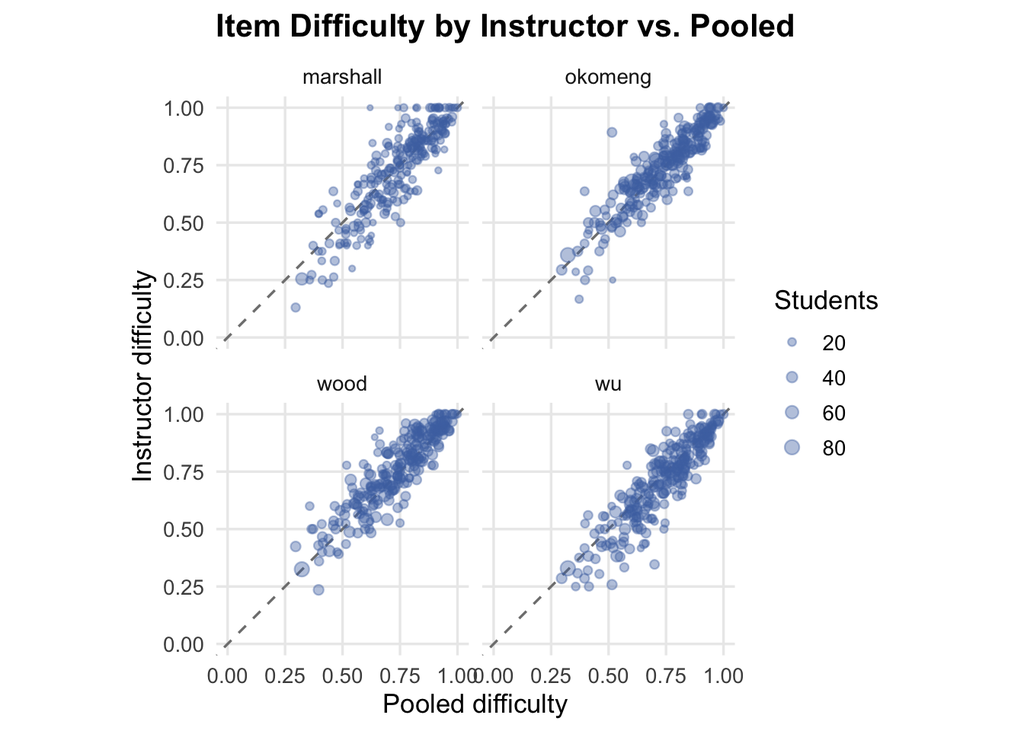

```r
pooled <- item_summary(clean)$items |>
  select(exam, question_title, pooled_difficulty = difficulty_index)

by_instructor <- item_summary(clean, by = "instructor")$items |>
  left_join(pooled, by = c("exam", "question_title"))

ggplot(
  by_instructor,
  aes(x = pooled_difficulty, y = difficulty_index, size = answered_student_count)
) +
  geom_abline(linetype = "dashed", color = "grey50") +
  geom_point(alpha = 0.4, color = "#4C72B0") +
  facet_wrap(~instructor) +
  scale_size_area(max_size = 3) +
  coord_equal(xlim = c(0, 1), ylim = c(0, 1)) +
  labs(
    title = "Item Difficulty by Instructor vs. Pooled",
    x = "Pooled difficulty",
    y = "Instructor difficulty",
    size = "Students"
  ) +
  theme_minimal(base_size = 13) +
  theme(plot.title = element_text(face = "bold"), panel.grid.minor = element_blank())
```

## What is the variance in difficulty for each question for each instructior

The distance of each point from the line is `difficulty_index - pooled_difficulty`, so a histogram of this difference per instructor shows the variance directly.

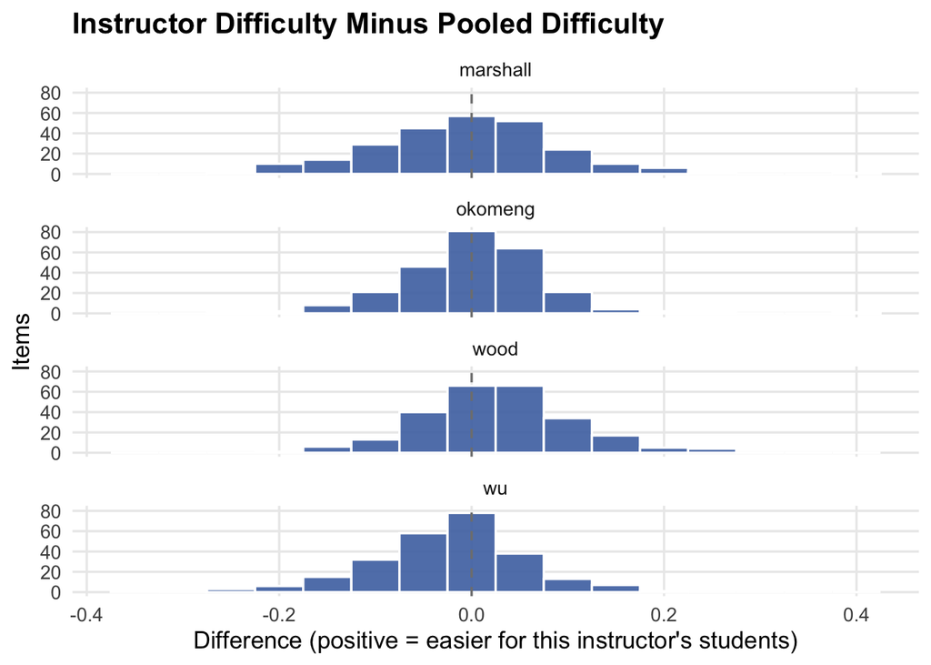

```r
by_instructor <- by_instructor |>
  mutate(diff_from_pooled = difficulty_index - pooled_difficulty)

spread_summary <- by_instructor |>
  summarise(
    n_items = n(),
    median_students = median(answered_student_count),
    mean_diff = mean(diff_from_pooled, na.rm = TRUE),
    sd_diff = sd(diff_from_pooled, na.rm = TRUE),
    sampling_sd = sqrt(mean(variance / answered_student_count, na.rm = TRUE)),
    .by = instructor
  )

ggplot(by_instructor, aes(x = diff_from_pooled)) +
  geom_histogram(binwidth = 0.05, fill = "#4C72B0", color = "white", alpha = 0.9) +
  geom_vline(xintercept = 0, linetype = "dashed", color = "grey50") +
  facet_wrap(~instructor, ncol = 1) +
  labs(
    title = "Instructor Difficulty Minus Pooled Difficulty",
    x = "Difference (positive = easier for this instructor's students)",
    y = "Items"
  ) +
  theme_minimal(base_size = 13) +
  theme(plot.title = element_text(face = "bold"), panel.grid.minor = element_blank())
```

# Multilevel Model

Students saw different random subsets of items, so total score is not a comparable ability measure across students. The model estimates ability from whatever items each student answered (student random effect), item difficulty (item random effect), and how much each item’s difficulty shifts by instructor (item × instructor random effect). Instructor is a fixed effect because there are only four.

```r
model_data <- clean |>
  filter(answered) |>
  mutate(
    item = paste(exam, question_title, sep = " | "),
    across(c(id, section_id, item, instructor, exam), as.factor)
  )

m0 <- glmer(
  correct ~ exam + instructor +
    (1 | id) +
    # (1 | section_id) +
    (1 | item),
  data = model_data,
  family = binomial,
  control = glmerControl(optimizer = "bobyqa")
)

m1 <- update(m0, . ~ . + (1 | item:instructor))
```

## Does item difficulty depend on instructor?

The variance is tested at its boundary (zero), so the reported p-value is conservative. Halving it gives the usual correction.

```r
test_likelihoodratio(m0, m1)
```

```
# Likelihood-Ratio-Test (LRT) for Model Comparison (ML-estimator)

Name |    Model | df | df_diff | Criterion | Chi2 |     p
---------------------------------------------------------
m0   | glmerMod |  8 |         |  24941.99 |      |
m1   | glmerMod |  9 |       1 |  24932.86 | 9.13 | 0.003
```

Adding a random intercept for item X instructor improved fit, $\chi^2(1) = 9.13, p = .001$.

```r
model_parameters(m1, effects = "random")
```

```
# Random Effects

Parameter                       | Coefficient | 95% CI
------------------------------------------------------
SD (Intercept: item:instructor) |        0.20 |
SD (Intercept: id)              |        0.82 |
SD (Intercept: item)            |        0.93 |
```

```r
icc(m1, by_group = TRUE)
```

```
# ICC by Group

Group           |   ICC
-----------------------
item:instructor | 0.008
id              | 0.137
item            | 0.178
```

Exam items differed in difficulty by a SD of 0.93 logits. For a typical Marshall student on a typical Exam 1 item, the odds of a correct answer are 3.77 ($\ln(3.77) = 1.33$), or a probability of .79. An item 1 SD easier than average has 2.53 times the odds of a correct answer ($\exp(0.93) = 2.53$), or $P = \frac{1}{1 + e^{-(1.33 + 0.93)}} = \frac{1}{1 + 0.104} = .906$ or 90.6%. An item 1 SD harder than average has 0.395 times the odds of a correct answer ($\exp(-0.93) = \frac{1}{e^{0.93}} = \frac{1}{2.53} = 0.395$), or $P = \frac{1}{1 + e^{-(1.33 - 0.93)}} = \frac{1}{1 + 0.670} = .599$ or 59.9%.

Students differed in ability by a SD of 0.82 logits. Using the same baseline, a student 1 SD above the mean has 2.27 times the odds of a correct answer ($\exp(0.82) = 2.27$), or $P = \frac{1}{1 + e^{-(1.33 + 0.82)}} = \frac{1}{1 + 0.116} = .896$ or 89.6%. A student 1 SD below the mean has 0.44 times the odds of a correct answer ($\exp(-0.82) = \frac{1}{e^{0.82}} = \frac{1}{2.27} = 0.44$), or $P = \frac{1}{1 + e^{-(1.33 - 0.82)}} = \frac{1}{1 + 0.601} = .625$ or 62.5%.

Item difficulty shifted for a given instructor’s students by a SD of 0.20 logits. Using the same baseline, an item 1 SD easier for one instructor’s students than its overall difficulty would predict has 1.22 times the odds of a correct answer ($\exp(0.20) = 1.22$), or $P = \frac{1}{1 + e^{-(1.33 + 0.20)}} = \frac{1}{1 + 0.217} = .822$ or 82.2%. An item 1 SD harder for one instructor’s students has 0.819 times the odds of a correct answer ($\exp(-0.20) = \frac{1}{e^{0.20}} = \frac{1}{1.22} = 0.819$), or $P = \frac{1}{1 + e^{-(1.33 - 0.20)}} = \frac{1}{1 + 0.323} = .756$ or 75.6%.

Exam item account for 17.8% of the variance in answering correctly, student differences account for 13.7%, and only 0.8% of the variance in answering correctly is due to instructor specific item shifts.

## Instructor differences in overall performance

```r
model_parameters(m1, effects = "fixed", exponentiate = TRUE)
```

```
# Fixed Effects

Parameter            | Odds Ratio |   SE |       95% CI |     z |      p
------------------------------------------------------------------------
(Intercept)          |       3.77 | 0.58 | [2.79, 5.11] |  8.59 | < .001
exam [exam_02]       |       1.31 | 0.19 | [0.98, 1.75] |  1.82 | 0.068
exam [exam_03]       |       0.66 | 0.10 | [0.49, 0.88] | -2.80 | 0.005
instructor [okomeng] |       1.06 | 0.17 | [0.78, 1.44] |  0.39 | 0.699
instructor [wood]    |       1.20 | 0.19 | [0.88, 1.63] |  1.15 | 0.250
instructor [wu]      |       0.88 | 0.14 | [0.65, 1.19] | -0.86 | 0.389
```

Each instructor is compared with Marshall on the same exam, and each exam with Exam 1 for the same instructor. A typical Marshall student on a typical Exam 1 item has odds of 3.77 to 1 of answering correctly (*OR* = 3.77, *SE* = 0.58, 95% CI [2.79, 5.11]), a probability of .79. Exam 2 items had 31% higher odds of a correct answer than Exam 1 items (*OR* = 1.31, *SE* = 0.19, 95% CI [0.98, 1.75], *p* = .068), a probability of .83 for a typical Marshall student, though the interval includes 1. Exam 3 items had 34% lower odds of a correct answer than Exam 1 items (*OR* = 0.66, *SE* = 0.10, 95% CI [0.49, 0.88], *p* = .005), a probability of .71.

Compared to Marshall’s students on the same exam, Okomeng’s students had 6% higher odds of answering correctly (*OR* = 1.06, *SE* = 0.17, 95% CI [0.78, 1.44], *p* = .699; probability .80 on Exam 1), Wood’s students had 20% higher odds (*OR* = 1.20, *SE* = 0.19, 95% CI [0.88, 1.63], *p* = .250; probability .82), and Wu’s students had 12% lower odds (*OR* = 0.88, *SE* = 0.14, 95% CI [0.65, 1.19], *p* = .389; probability .77). **No instructor’s students differed significantly from Marshall’s. Only Exam 3 differed significantly from Exam 1.**

## Instructor Means

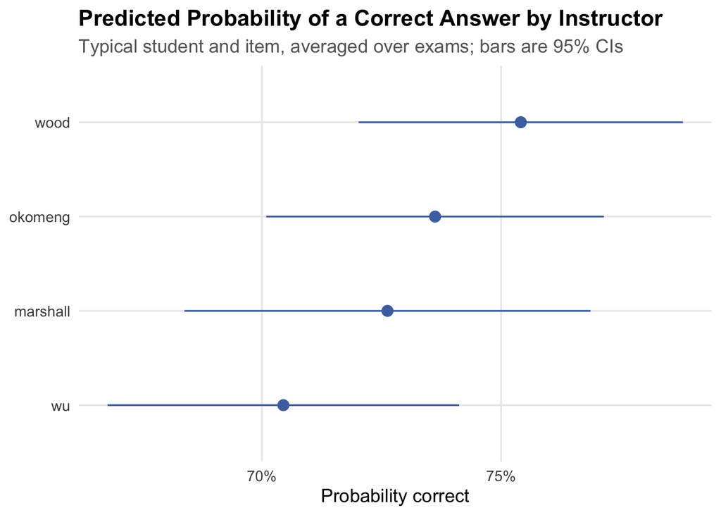

```r
instr_means <- estimate_means(m1, by = "instructor")

instr_means |>
  as_tibble() |>
  ggplot(aes(x = Probability, y = fct_reorder(instructor, Probability))) +
  geom_pointrange(aes(xmin = CI_low, xmax = CI_high), color = "#4C72B0") +
  scale_x_continuous(labels = scales::percent_format()) +
  labs(
    title = "Predicted Probability of a Correct Answer by Instructor",
    subtitle = "Typical student and item, averaged over exams; bars are 95% CIs",
    x = "Probability correct",
    y = NULL
  ) +
  theme_minimal(base_size = 13) +
  theme(
    plot.title = element_text(face = "bold"),
    plot.subtitle = element_text(color = "grey40"),
    panel.grid.minor = element_blank()
  )
```

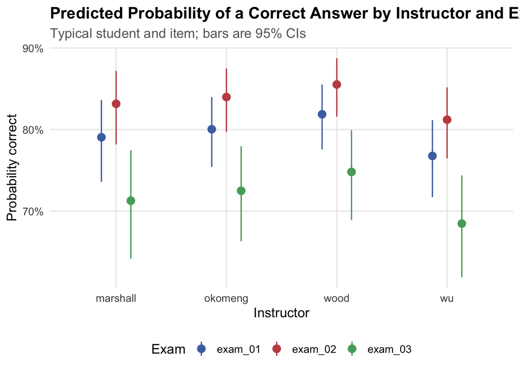

```r
estimate_relation(m1, by = c("instructor", "exam")) |>
  as_tibble() |>
  ggplot(aes(x = instructor, y = Predicted, color = exam)) +
  geom_pointrange(
    aes(ymin = CI_low, ymax = CI_high),
    position = position_dodge(width = 0.4)
  ) +
  scale_y_continuous(labels = scales::percent_format()) +
  scale_color_manual(values = c("#4C72B0", "#C44E52", "#55A868")) +
  labs(
    title = "Predicted Probability of a Correct Answer by Instructor and Exam",
    subtitle = "Typical student and item; bars are 95% CIs",
    x = "Instructor",
    y = "Probability correct",
    color = "Exam"
  ) +
  theme_minimal(base_size = 13) +
  theme(
    plot.title = element_text(face = "bold"),
    plot.subtitle = element_text(color = "grey40"),
    panel.grid.minor = element_blank(),
    legend.position = "bottom"
  )
```

## Items flagged for instructor-specific difficulty

Item × instructor deviations whose 95% interval excludes zero. Positive values mean the item was easier for that instructor’s students than expected.

```r
item_flags <- estimate_grouplevel(m1) |>
  as_tibble() |>
  filter(Group == "item:instructor") |>
  mutate(
    instructor = str_extract(Level, "[^:]+$"),
    item = str_remove(Level, ":[^:]+$")
  ) |>
  separate_wider_delim(item, delim = " | ", names = c("exam", "question_title"), too_many = "merge") |>
  filter(CI_low > 0 | CI_high < 0) |>
  select(exam, question_title, instructor, Coefficient, CI_low, CI_high) |>
  arrange(exam, question_title)

item_flags |> select(-question_title)
```

```
# A tibble: 0 × 5
# ℹ 5 variables: exam <chr>, instructor <chr>, Coefficient <dbl>, CI_low <dbl>,
#   CI_high <dbl>
```

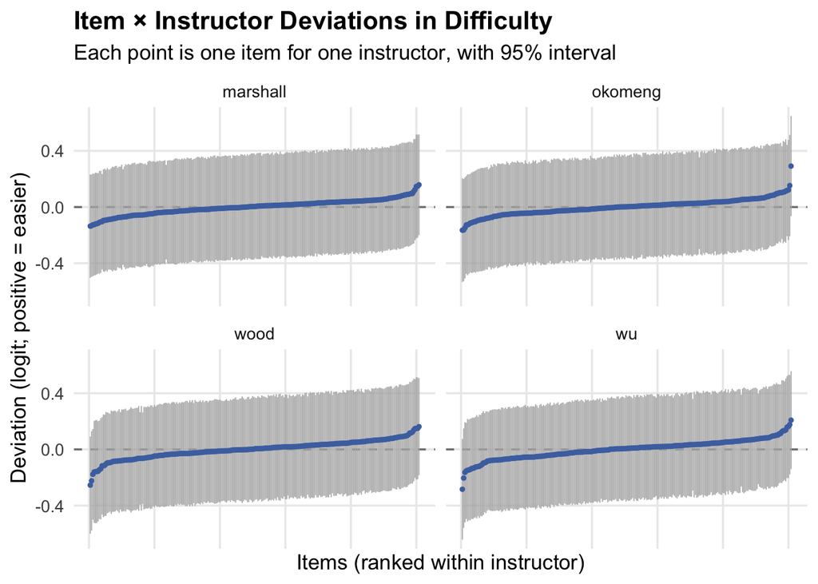

```r
item_instructor <- estimate_grouplevel(m1) |>
  as_tibble() |>
  filter(Group == "item:instructor") |>
  mutate(
    instructor = str_extract(Level, "[^:]+$"),
    rank = rank(Coefficient, ties.method = "first"),
    .by = NULL
  ) |>
  mutate(rank = rank(Coefficient, ties.method = "first"), .by = instructor)

ggplot(item_instructor, aes(x = rank, y = Coefficient)) +
  geom_hline(yintercept = 0, linetype = "dashed", color = "grey50") +
  geom_linerange(
    aes(ymin = CI_low, ymax = CI_high),
    color = "grey70",
    linewidth = 0.3
  ) +
  geom_point(color = "#4C72B0", size = 0.8) +
  facet_wrap(~instructor) +
  labs(
    title = "Item × Instructor Deviations in Difficulty",
    subtitle = "Each point is one item for one instructor, with 95% interval",
    x = "Items (ranked within instructor)",
    y = "Deviation (logit; positive = easier)"
  ) +
  theme_minimal(base_size = 13) +
  theme(
    plot.title = element_text(face = "bold"),
    panel.grid.minor = element_blank(),
    axis.text.x = element_blank()
  )
```

# Assumption testing

```r
# Fitting
check_convergence(m1)
```

```
[1] FALSE
attr(,"gradient")
[1] NA
```

```r
check_singularity(m1)
```

```
[1] FALSE
```

```r
# Fixed effects
check_collinearity(m1)
```

```
# Check for Multicollinearity

Low Correlation

       Term  VIF   VIF 95% CI adj. VIF Tolerance Tolerance 95% CI
       exam 1.00 [1.00, 1.00]     1.00      1.00     [1.00, 1.00]
 instructor 1.00 [1.00, 1.00]     1.00      1.00     [1.00, 1.00]
```

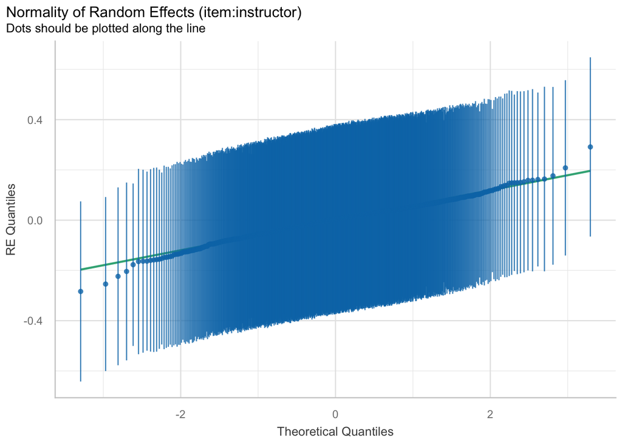

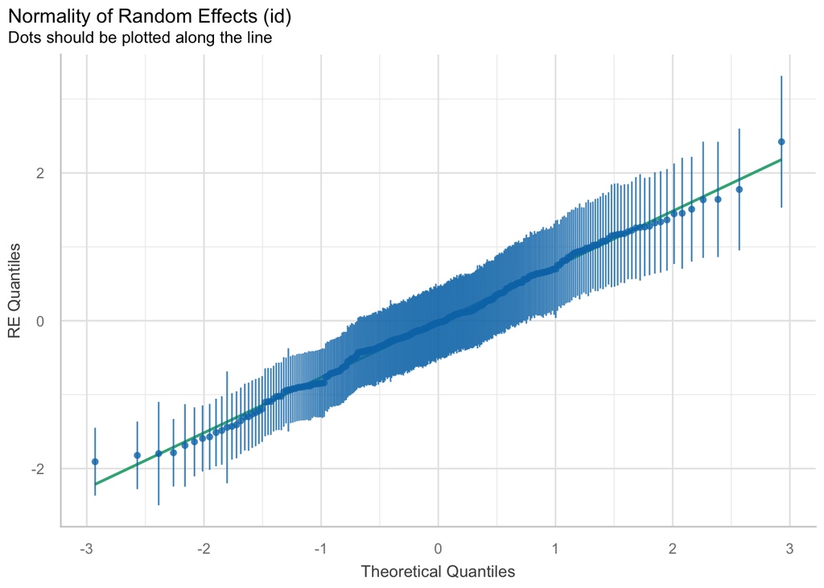

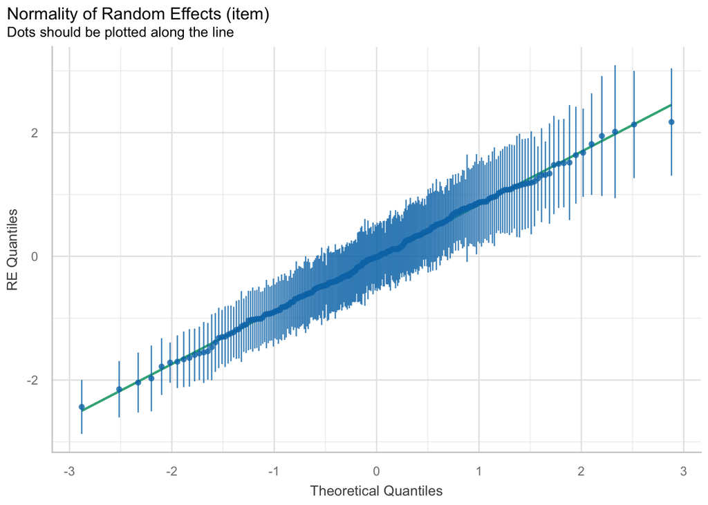

```r
# Random effects
check_normality(m1, effects = "random")
plot(check_normality(m1, effects = "random"))
```

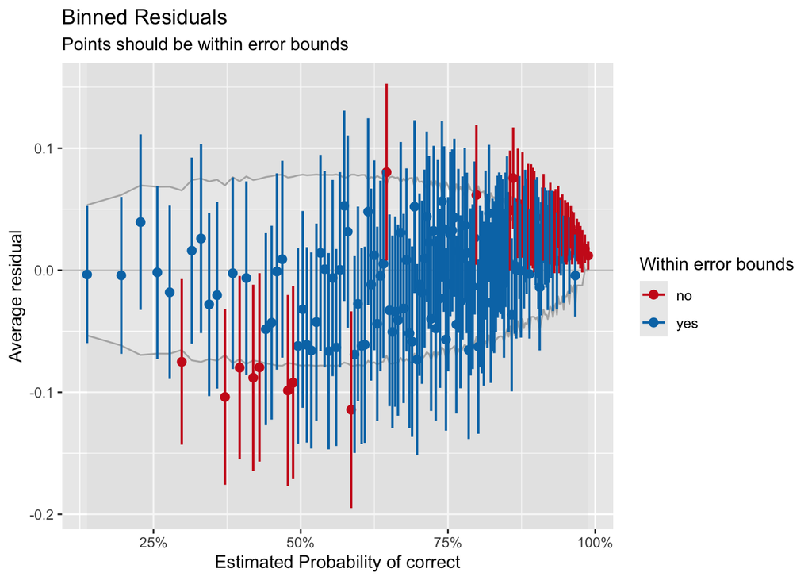

```r
# Fit of predicted vs. observed probabilities
binned_residuals(m1)
plot(binned_residuals(m1))
```

```r
# Did glmer report convergence problems when fitting?
m1@optinfo$conv$lme4
```

```r
m1@optinfo$warnings
```

```
list()
```

```r
# Which item is the outlier at about -5?
estimate_grouplevel(m1) |>
  as_tibble() |>
  filter(Group == "item") |>
  arrange(Coefficient) |>
  slice_head(n = 5) |>
  separate_wider_delim(
    Level,
    delim = " | ",
    names = c("exam", "question_title"),
    too_many = "merge"
  ) |>
  left_join(
    item_summary(clean)$items |>
      select(exam, question_title, answered_student_count, difficulty_index),
    by = c("exam", "question_title")
  ) |>
  select(exam, Coefficient, answered_student_count, difficulty_index)
```

```
# A tibble: 5 × 4
  exam    Coefficient answered_student_count difficulty_index
  <chr>         <dbl>                  <int>            <dbl>
1 exam_02       -2.44                    125            0.296
2 exam_02       -2.15                    104            0.365
3 exam_02       -2.04                     86            0.372
4 exam_01       -1.97                     70            0.357
5 exam_02       -1.78                     98            0.439
```

```r
hardest_items <- estimate_grouplevel(m1) |>
  as_tibble() |>
  filter(Group == "item") |>
  arrange(Coefficient) |>
  slice_head(n = 5) |>
  separate_wider_delim(
    Level,
    delim = " | ",
    names = c("exam", "question_title"),
    too_many = "merge"
  ) |>
  left_join(
    item_summary(clean)$items |>
      select(exam, question_title, answered_student_count, difficulty_index),
    by = c("exam", "question_title")
  ) |>
  select(exam, Coefficient, answered_student_count, difficulty_index)

hardest_items
```

```
# A tibble: 5 × 4
  exam    Coefficient answered_student_count difficulty_index
  <chr>         <dbl>                  <int>            <dbl>
1 exam_02       -2.44                    125            0.296
2 exam_02       -2.15                    104            0.365
3 exam_02       -2.04                     86            0.372
4 exam_01       -1.97                     70            0.357
5 exam_02       -1.78                     98            0.439
```

```r
resid_band <- model_data |>
  mutate(fitted = fitted(m1), resid = correct - fitted) |>
  filter(fitted >= 0.30, fitted <= 0.60)

# By item
resid_band |>
  summarise(n = n(), mean_resid = mean(resid), .by = item) |>
  arrange(mean_resid) |>
  slice_head(n = 10) |>
  select(-item)
```

```
# A tibble: 10 × 2
       n mean_resid
   <int>      <dbl>
 1     1     -0.572
 2     4     -0.552
 3     3     -0.546
 4     3     -0.537
 5     2     -0.521
 6     2     -0.512
 7     5     -0.500
 8     8     -0.389
 9     7     -0.361
10     6     -0.331
```

```r
# By exam and instructor
resid_band |>
  summarise(n = n(), mean_resid = mean(resid), .by = c(exam, instructor)) |>
  arrange(mean_resid)
```

```
# A tibble: 12 × 4
   exam    instructor     n mean_resid
   <fct>   <fct>      <int>      <dbl>
 1 exam_02 marshall     236   -0.123
 2 exam_01 wu           556   -0.0617
 3 exam_03 wood         571   -0.0551
 4 exam_02 wu           380   -0.0530
 5 exam_03 okomeng      619   -0.0473
 6 exam_01 marshall     265   -0.0437
 7 exam_01 wood         339   -0.0425
 8 exam_03 marshall     420   -0.0266
 9 exam_02 okomeng      285   -0.0231
10 exam_01 okomeng      408   -0.0148
11 exam_03 wu           725    0.00344
12 exam_02 wood         282    0.0327
```

```r
sim <- simulate_residuals(m1)
check_residuals(sim)
```

```
OK: Simulated residuals appear as uniformly distributed (p = 0.206).
```

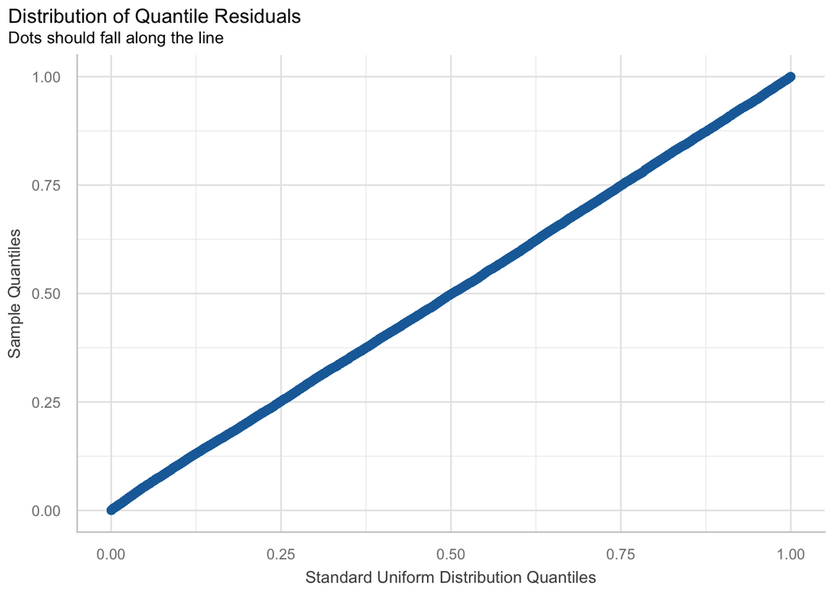

```r
plot(sim)
```

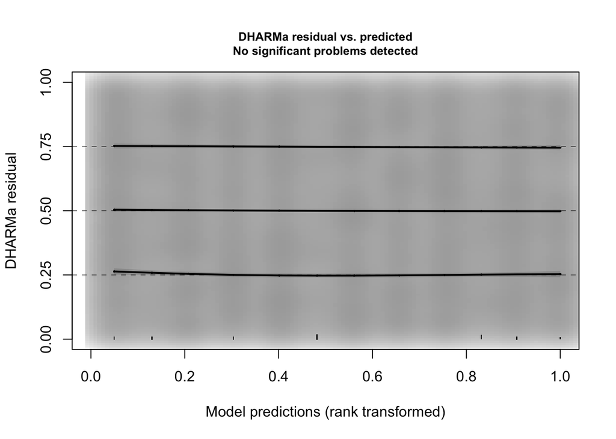

```
    Test for location of quantiles via qgam

data:  res
p-value = 0.8822
alternative hypothesis: both
```

```r
DHARMa::testQuantiles(sim)
```